# 2 How We Can Acquire COVID-19 Data, Just Like Epidemiologists

Pirneeta R. Bhambhani

05/01/2021

# Part 1: Data Science, and Epidemiology!

- Epidemiologists gain visibility to gather specific data: Obtaining detailed, accurate and current data for the COVID-19 pandemic may not seem as straightforward as it is; how can we keep ourselves updated, when every single day all news channels are overwhelmed by new, and cumulatively growing numbers? Keeping updated is essential as the statistics retrieved are used to aid planning and assessing of the required public health response.
- Data science aids in efficient future planning: Encountering inconveniences globally with having insufficient number of hospital beds and caregivers to support the exponentially growing number of patients, there have been cases in India where trains and truck containers had to be innovatively used as hospital space.
- RECAP: ‘R’ provides a quick and easy yielding of R libraries to analyze outbreak! R is just one example for a great tool that can be used efficiently by only a small team of data scientists to aid future planning. Data science can now help Epidemiologists to decide the rate and distribution of the vaccines, corresponding to the number of growing cases in local regions.

### Societal victims of COVID-19:

National and Global level: Healthcare wants to know if the current restrictions will support or hinder its limited capacity to cope with the most seriously ill that require hospital care. Businesses want to know how long the business restrictions will be in place as they seriously impact their revenues, keeping jobs, opening credit lines. It all depends on the length of time, and depth of the crisis.

Governments: they want to know how much money from the budget to allocate towards helping businesses, how harsh the restrictions should be and for how long, and how strongly they are supposed to be enforced to be effective.

# 2.1 Case Study 1: Taiwan’s proactive control towards COVID-19

- Taiwan: Constant alert, ready to act on epidemics arising from China ever since the SARS Epidemic (2003).
- COVID-19 occurred just before the Lunar New Year during which time millions of Chinese and Taiwanese were expected to travel for the holidays.
- Mobilized: they mobilized and instituted specific approaches for case identification, containment, and resource allocation.
- Leveraged: its national health insurance database and integrated it with its immigration and customs database to begin the creation of big data for analytics.
- Real-time alerts based on travel history aided clinical visits.
- New Technology: QR code scanning and online reporting.

The image below is a campaign that was released in Taiwan, highlighting and reinforcing the utilisation of new technology to ensure the efficacy of border and case control.

[figure not shown]

Figure 1: Taiwan’s Model for combating COVID-19

### How was Taiwan prepared to recognize the crisis? (Jama Network, 2021)

- National Health Command Center (NHCC) was established in 2004 after SARS. The Taiwan government established the National Health Command Center (NHCC) which is part of a disaster management center that focuses on large-outbreak such as COVID-19.
- Unified a Central command system including: Central Epidemic Command Center (CECC), Biological Pathogen Disaster Command Center (BPDCO), Counter-Bioterrorism command center, and he Central Meical Emergency Operations Center.
- December 31st ’20: WHO notified of unknown pneumonia.
- January 20th ’20: Taiwan Centers for Disease Control (CDC) activated the CECC
- January 27th ‘20: National Health Insurance Administration (NHIA) & the National Immigration Agency integrated patients’ last 14-day travel history. The Taiwan “citizens’ household registration system”and the “foreigners’ entry card” allowed the government to track individuals at high risk because of recent travel history in affected areas.
- January 30th ’20: NHIA expanded their database to include data of travelers from China, Hong Kong and Macaw.
- February 14th ’20: Launch of “Entry Quarantine System”, completing health declaration by scanning a QR code. This system was created within 72 hours.
- February 18th ‘20: Government officially announced that pharmacies, hospitals and clinics have access to all patients’ travel histories.

[figure not shown]

Figure 2: Epidemic curve of weekly cases, comparing Taiwan to New Zealand

# Part 2: How sure can we be, that our data is accurate?

### Incidence Data by John Hopkins University (JHU)

- Widely used source that collates data from governmental websites
- Factors such as time-zone differences can be taken into account
- Time-series format, making results more efficient

It’s possible that: Epidemiologists want to remove the number of people on board from the collated data for a particular period of time with assumptions such as: They were quarantined!

# 2.2 Case Study 2: “Diamond Princess Cruise ship Case”

Let’s assume this case as an example for data that we want to eliminate from our collated data.

### Why eliminate the Diamond Princess Cruise Ship case numbers?

- 712 people were infected with COVID-19 on the cruise ship.
- Quarantined for around two weeks.
- All passengers and crew members had finally disembarked the ship by March 1, 2020.
- The cruise ship was on a 14-day round trip that departed from Yokohama, Japan, on January 20, 2020.
- A guest tested positive for COVID-19 after disembarking in Hong Kong. The cruise was delayed.
- Screening for the virus took place on board the ship
- The number of positive cases increased, it was confirmed that the ship would remain quarantined until February 19, 2020.
- The quarantine period ended by 27th February instead.

So, once again, We can assume that the number of people on board were quarantined during the chosen period of time, making it less likely to increase the number of cases.

[figure not shown]

Figure 3: Diamond Princess Cruise Ship, February 2020

It’s always possible to compare data. But first, it is important to pay attention to the time-value of results! To receive efficient results, JHU’s results must be shifted back by one day. Why?- Original dates are with respect to the Greenwich Time (Midnight UTC). This is efficient for combining our JHU and Wikipedia results, by referring to the local US time zones.

# 2.3 Comparing Publicly Available Data: JHU and Wikipedia

### John Hopkin’s University

- Aim: searching for COVID-19 cases in the USA from start (zero cases) to 5th March 2020.
- Excluding the Diamond Princess Cruise Ship
- Needed: R package. To make things easy, we just have to follow the code that has already been provided by this website, known as “R views:”

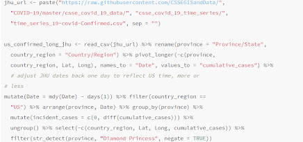

Figure 4: Easy-to-follow-R-coding

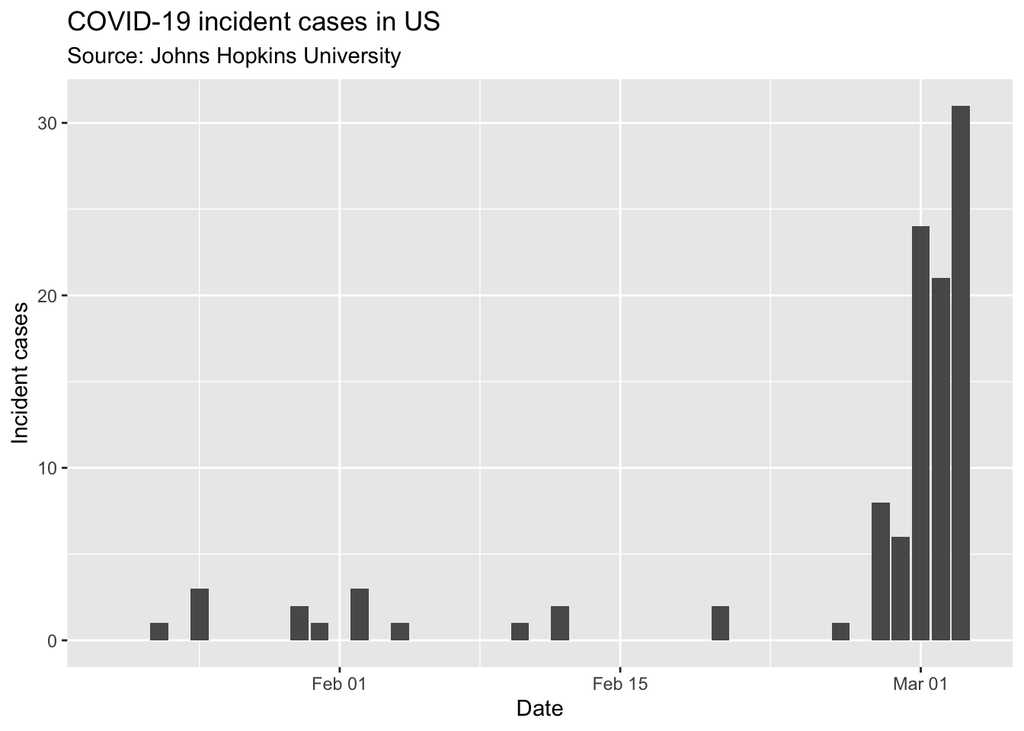

Figure 5: JHU data for Covid-19 Cases from start to 5th March 2020

### Wikipedia

- The wikipedia page on COVID-19 in the US contains several tables, one of which contains a line-listing of all the initial US cases, which at the time of writing appeared to be fairly complete up to 2nd March.
- Data Wrangling: A method used to convert the tabular data into a usable format
- A recommended package to be used: “rvest” package (Part of “tidyverse”).
- R can be used to quickly group and analyze data into tabular and graphical format.
- Once again, our focus is on a: Particular period of time from beginning (Zero Cases) to the 5th March 2020.

The following code can be retrieved from the “R-views” link: https://rviews.rstudio.com/2020/03/05/covid-19-epidemiology-with-r/

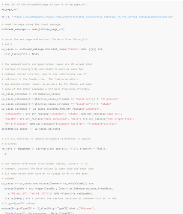

Figure 6: Scraping the data that we need from Wikipedia with R

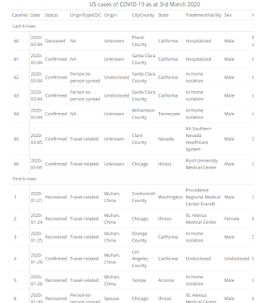

Figure 7: Tabular data from Wikipedia

## Comparing in Graphical Format:

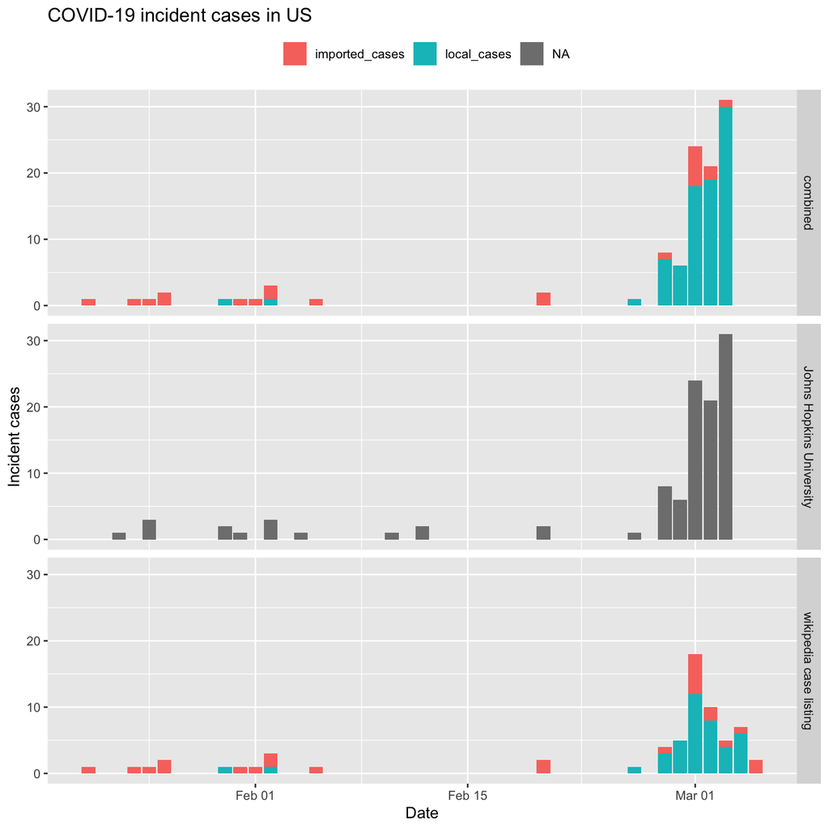

Figure 8: The final Comparison